# Notebook

### Chapter 1

### Data description

- **Graphical description**
  - **Quantitative (numerical) data**
    - **Histogram** (overall shape of the distribution)
    - **Boxplot** (median, quartiles, outliers)
    - **Dot plot / strip chart** (useful for small samples)
    - **Stem-and-leaf plot** (shows values while displaying distribution)
    - **Density plot** (smoothed version of a histogram)
    - **Time plot** (for time series; trend/seasonality)
    - **Scatterplot** (when studying the relationship between two quantitative variables)

    ...
  - **Qualitative (categorical) data**
    - **Bar chart** (counts or proportions in each category)
    - **Pie chart** (proportions; best with a small number of categories)
    - ...
- **Numerical description**
  - **Center**
    - Mean, median, mode
  - **Spread (variability)**
    - Range, variance, standard deviation, IQR
  - **Position (relative standing)**
    - Percentiles, quartiles, z-scores
  - **Shape**
    - Skewness (left/right skew), kurtosis (tail/heaviness) ,...
  - **Association (when there are two variables)**
    - Covariance, correlation, ...

```r
# Load the data

file.0 = "diamond.csv"

#the names of variables are in the .csv file
dat = read.csv(file.0,  header = 1)

head(dat)
```

A data.frame: 6 × 5

|  | Weight <dbl> | Color <chr> | Clarity <chr> | Certificate <chr> | Price <int> |
| --- | --- | --- | --- | --- | --- |
| 1 | 0.30 | D | VS2 | GIA | 1302 |
| 2 | 0.30 | E | VS1 | GIA | 1510 |
| 3 | 0.30 | G | VVS1 | GIA | 1510 |
| 4 | 0.30 | G | VS1 | GIA | 1260 |
| 5 | 0.31 | D | VS1 | GIA | 1641 |
| 6 | 0.31 | E | VS1 | GIA | 1555 |

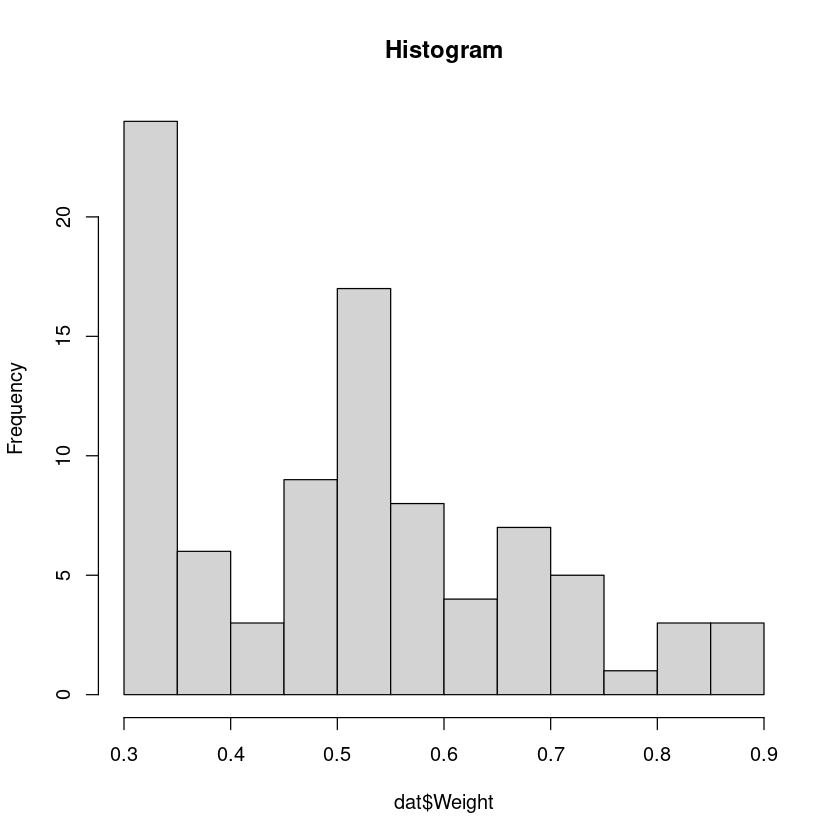

```r
#Weight
#Histogram
hist(dat$Weight, breaks=10, main="Histogram")
#Skewed to the right (longer tail on the right), bimodal , ...
```

```
 D  E  F  G  H  I
 4 16 27 18 17  8
```

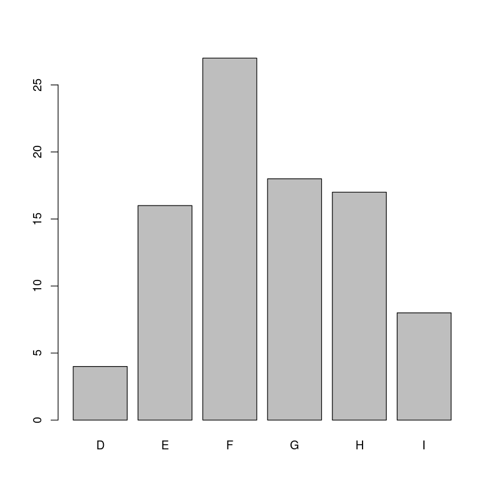

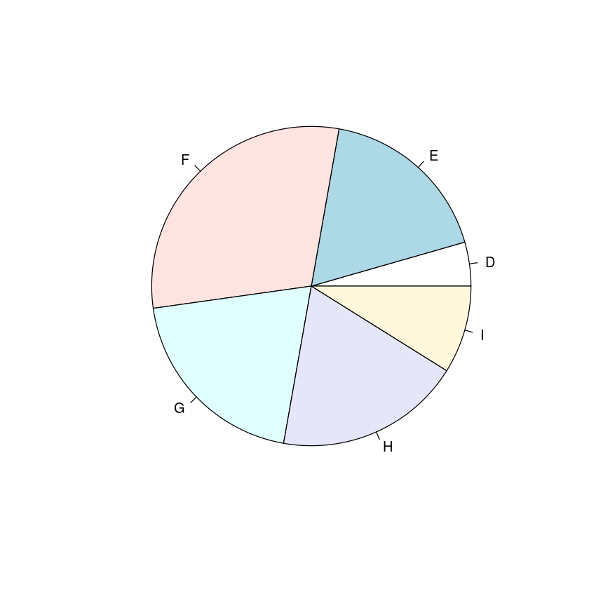

```r
#Bar chart
tab.color = table(dat$Color)
tab.color
barplot(tab.color)

pie(tab.color)
```

#### Numerical description of univariate data

- **Center (a number to summarize the data):**
  - **Mean** (arithmetic average): $\bar{x}=\frac{1}{n}\sum_{i=1}^n x_i$
  - **Median** (middle value when the data are ordered)
  - **Mode** (most frequent value)
- **Mean vs. median:** The **median** is more robust to outliers than the mean. When the distribution is highly skewed or contains outliers, we often prefer the **median** as a measure of center.
- **Other types of “averages”:**
  - **Geometric mean** (typically for positive data, especially multiplicative growth): $$ \bar{x}_G=\sqrt[n]{x_1x_2\cdots x_n} =\left(\prod_{i=1}^{n} x_i\right)^{1/n} $$
  - **Harmonic mean** (typically for averaging rates/ratios): $$ \bar{x}_H=\frac{n}{\sum_{i=1}^{n}\frac{1}{x_i}} $$ The harmonic mean equals the number of observations divided by the sum of their reciprocals. It is often useful for ratios such as speed $(=\text{distance}/\text{time})$.
- **Example use of the harmonic mean (genetics):**
  - **Heterozygosity levels** (context-dependent measure in population genetics).
  - **Effective population size ($N_e$):** the size of an idealized population (where every individual reproduces) that would experience genetic drift at the same rate as the actual population. Because genetic drift is strongly affected by the smallest population sizes across generations, the effective population size over multiple generations is often better represented by a **harmonic mean** rather than an arithmetic mean.

```r
#Question: Find the mean weight, the median weight, the geometric mean of weight,  the harmonic mean of weight.
# when all data values are positive,
  mean(dat$Weight)
  median(dat$Weight)

#To cacluate the geometric mean
  n = length(dat$Weight)
  GMean = (prod(dat$Weight))^(1/n)
  GMean

#To calculate  the harmonic mean
 HMean = n/sum((1/dat$Weight))
 HMean

##Question: Please find the mean price, the median price, the geometric mean of price,  the harmonic mean of price
```

0.514555555555556

0.515

0.48991077056153

0.466405575987572

```r
#To calculate  the harmonic mean
 HMean = n/sum((1/dat$Price))
 HMean
```

2433.95561416412

#### Numerical description of a univariate data

--- Spread out

#### Numerical description of univariate data

- **Spread (how spread out the data are):**

[figure not shown]

- **Variance and standard deviation:**
  - $s$: the **sample standard deviation**
  - $s^2$: the **sample variance**

  If $x_1,\dots,x_n$ are sample values and $$\bar{x}=\frac{1}{n}\sum_{i=1}^n x_i,$$ then the **sample standard deviation** is $$ s=\sqrt{\frac{1}{n-1}\sum_{i=1}^n (x_i-\bar{x})^2 }. $$ So the sample variance is $$ s^2=\frac{1}{n-1}\sum_{i=1}^n (x_i-\bar{x})^2. $$
- **Range:**
  $$ \text{Range}=\max(x)-\min(x). $$
- **Interquartile range (IQR):**
  $$ \text{IQR}=Q_3-Q_1, $$ where $Q_1$ is the first quartile (25th percentile) and $Q_3$ is the third quartile (75th percentile).
- **Robustness:**  
  The IQR is **robust to outliers**, meaning extreme values have little effect on it.

```r
#Find the sample standard deviation, the variance, the range, IQR for the weight

#Standard deviation -
  s = sd(dat$Weight)
  s

#Variance
  Var.weight = var(dat$Weight)
  Var.weight

#Range
  Range = max(dat$Weight) - min(dat$Weight)
  Range

#IQR  - robust
 IQR(dat$Weight)
```

0.16187220032622

0.0262026092384519

0.6

0.265

### Position (relative standing)

$z-score$: the standardize value of a value for a distribution.

$$ z = (x - \mu)/\sigma $$ where $\mu$ is the mean, and $\sigma$ is the standard deviation of a distribution.

The percentile (quantile):

SAT score: 97th percentile - The score is above 97% of all SAT scores.

$100 \times p$-th percentile in data : The proportion of data values no more than the percentile is p.

# R function: scale.

```r
# calculate  all z-score of weight values
zscore = scale(dat$Weight)
#zscore
#z-score = -1.26, the weight of that diamond is 1.26 standard deviations below the average.

#Find 96-th percentile
quantile(dat$Weight, prob=c(0.96))

#96% of diamonds in the data have weights below 0.8444
```

**96%:** 0.8444

### Boxplot (simply version of boxplot)

To describe a distribution using five numbers, we have 5 number summary. The five number summary consists of min, Q1, Median, Q3, Max.

Q1: the 25-th percentile; Q3 is the 75-th percentile.

Ususally 5 number summary provide more informatio than the mean and the standard deviation. We may be able to tell if a distribution is skewed or not based on the five number summary.

Boxplot is the visual version of the five number summary. Software usually give us a modified version (with contains outliers information).

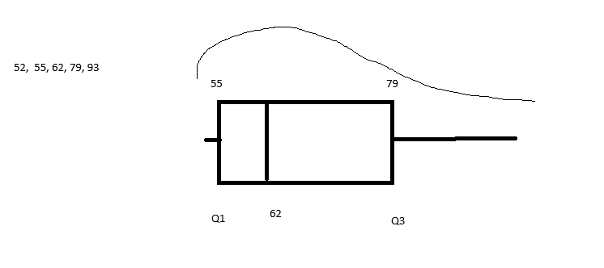

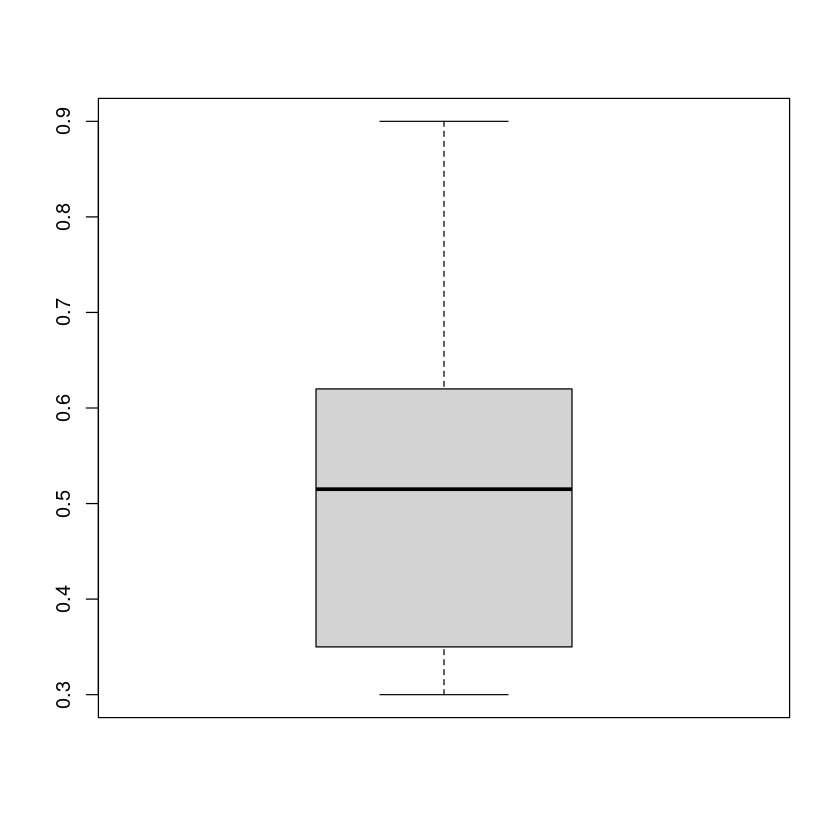

```r
#Boxplot for the weight variable
boxplot(dat$Weight)
```

### Skewness

**Skewness:** $$ skw =\frac{\sum_{i=1}^n (x_i-\bar{x})^3}{n\,s^3}, $$

If the data has a distribution which is postively skewed (skewed to the right), the skewness is above zero.

If the data has a distribution which is negatively skewed (skewed to the left), the skewness is below zero.

If the data has a distribution which is approximately symmetrical, the skewness is around zero.

#### Kurtosis (formula )

Kurtosis measures how peaked a distribution is.

**kurtosis:** $$ k=\frac{\sum_{i=1}^n (x_i-\bar{x})^4}{n\,s^4}-3, $$ where $s$ is the sample standard deviation.
Normal distribution has kurtosis $\approx 0$.

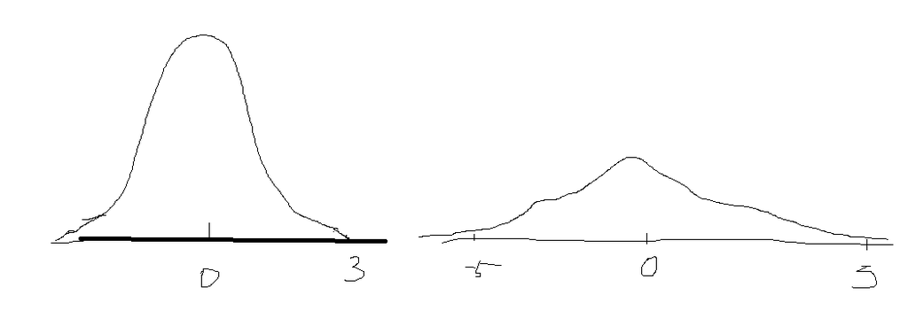

```r
### R code

x = c(-1,-1,5,10,20,30,40,15,12,7,6,60)

#function
kurtosis.fun = function(x00)
{
    x.bar = mean(x00)
    sx    = sd(x00)
    n = length(x00)

    kurt0 = sum(( x00 - x.bar)^4)/(n*sx^4) - 3

    return(kurt0)
}

kurtosis.fun(x00 = x)

#To find the kurtosis of weight

kurtosis.fun(dat$Weight)
#kurtosis -0.625934165356926,  indicating the distribution of weight is not heavy tailed.
```

0.0414565074002784

-0.625934165356926